# A3

### 2.3 Predicció

Segons el model de l’apartat 2.2 b), quina seria la probabilitat de baix pes en néixer, si la mare és fumadora i AD és de 90?

```r
model <- glm(formula= lower.BW ~ Sm + AD, data=df, family=binomial)
newdata = data.frame(Sm = "S", AD = 90)
predict(model, newdata, type="response")
```

```
## 1
## 1
```

### 2.4 Bondat de l’ajust

Usa el test de Hosmer-Lemeshow per a veure la bondat d’ajust del model final triat. En el package ResourceSelection hi ha una funció que ajusta el test de Hosmer-Lemeshow.

```r
library(ResourceSelection)
```

```
## ResourceSelection 0.3-5   2019-07-22
```

```r
hl <- hoslem.test(df$lower.BW, fitted(model), g=10)
hl
```

```
##
##  Hosmer and Lemeshow goodness of fit (GOF) test
##
## data:  df$lower.BW, fitted(model)
## X-squared = 5.8762e-07, df = 8, p-value = 1
```

```r
cbind(hl$observed,hl$expected)
```

```
##                y0 y1        yhat0 yhat1
## [0.197,0.946] 193 82 1.930000e+02    82
## (0.946,1]       0 25 5.876157e-07    25
```

### 2.5 Corba ROC

Dibuixar la corba ROC, i calcular l’àrea sota la corba. Discutir el resultat.

```r
library(pROC)
```

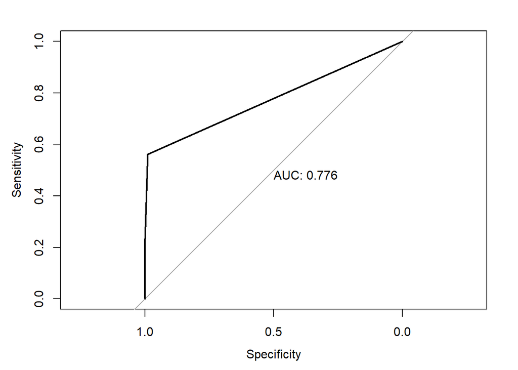

```r
test_prob = predict(model, newdata = df, type = "response")
test_roc = roc(df$lower.BW ~ test_prob, plot = TRUE, print.auc = TRUE)
```

No sé si acabo d’entendre la curva ROC o si l’he feta bé. Jo crec que la varialbe de la mare fumadora, tal com he vist abans és molt forta, creix molt ràpidament.

## 3 Conclusions de l’anàlisi

En aquest apartat s’hauran d’exposar les conclusions sobre la base dels resultats obtinguts en tot l’estudi. Regressió lineal i logística

Hem vist que la regressió lineal és prou útil per a predir variables numèriques amb un rang prou elevat. En canvi per a regressions logistiques, són necessàries variables binàries, 0 o 1.

També hem entrat més a fons la relació entre variables com el baix pes d’un nadó i si la mare és fumadora. Obtenim conclusions més acurades que la PAC anterior. Si la mare és fumadora, hi ha més probabilitats de que el fill neixi amb baix pes. En canvi, com el lloc de naixement, no hi influeix gens.